# 데이터 과학 – 기초 통계

범주형 데이터 분석

# 코딩기반 범부형 데이터 분석

코딩기반 통계적 추론을 살펴보자. 범주형 데이터의 가장 기본은 **비율(Proportion, $p$)**부터 시작한다. 성별을 얘기할 때, 남성과 여성의 비율이 대표적일 수 있다. 미국의 `GSS(General Socail Survey)`에 견주는 대한민국 [한국복지패널 데이터](https://www.koweps.re.kr:442/main.do)를 얻을 수 있는데, `stata`, `spss`, `sas` 등 상용통계팩키지에 의존성이 있어 이를 R과 같은 오픈소스 소프트웨어에서 작업할 경우 `haven` 팩키지를 동원해야 한다. 그리고 상당량의 변환작업과정과 데이터사전을 보고 일일이 데이터와 대조하는 과정을 거쳐야 한다.

그래서 `forcats` 팩키지에 내장되어 있는 `gss_cat` 범주형 데이터를 가지고 작업을 진행한다.

## 데이터 가져오기

`gss_cat` 데이터에서 2014년 데이터만 뽑아내서 범주형 데이터 분석을 위한 샘플데이터로 준비한다.

```r
# 0. 환경설정 -----
library(infer)
library(haven)
library(tidyverse)

# data(package="forcats")

gss_cat_df  <- gss_cat %>%
    filter(year==2014)
```

## 탐색적 데이터분석

본격적인 데이터 분석에 들어가기 앞서 가장 먼저 데이터에 익숙해지는 과정이 필요하다. 이를 위해서 탐색적 데이터 분석을 진행하는데, 데이터를 `glimpse`로 살펴보고, `ggplot`으로 시각화하고, 범주형 데이터에 대한 기술통계량을 뽑아보는 것부터 시작한다.

그리고 나서, 혼인상태(marital)에 대한 현재 혼인비율을 추정한다.

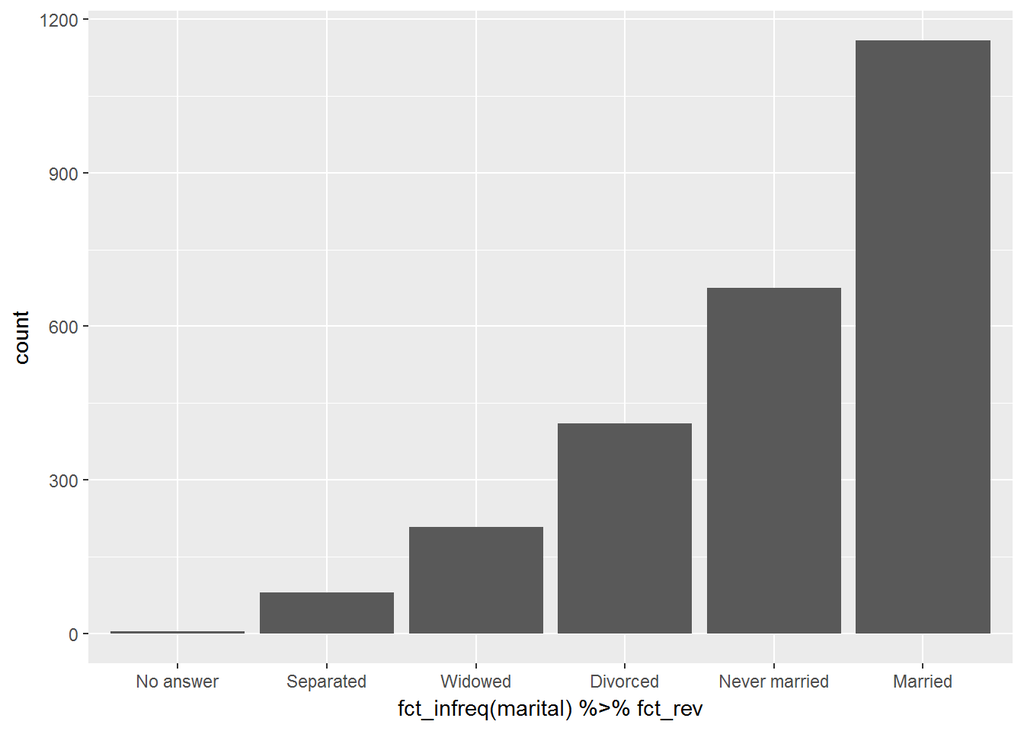

```r
# 2. 탐색적 데이터 분석 -----
## 2.1. 시각화 ----
gss_cat_df %>%
    ggplot(aes(x=fct_infreq(marital) %>% fct_rev)) +
    geom_bar()
```

```r
## 2.2. 기술통계량 ----
gss_cat_df %>%
    count(marital, sort=TRUE) %>%
    mutate(pcnt = scales::percent(n/sum(n)))
```

```
# A tibble: 6 x 3
  marital           n pcnt
  <fct>         <int> <chr>
1 Married        1158 45.6%
2 Never married   675 26.6%
3 Divorced        411 16.2%
4 Widowed         209 8.2%
5 Separated        81 3.2%
6 No answer         4 0.2%
```

```r
## 2.3. 이혼율 ----
(married_hat <- gss_cat_df %>%
    summarise(p = mean(marital == "Married")) %>%
    pull())
```

```
[1] 0.4562648
```

## 혼인비율 신뢰구간

`fct_lump()` 함수는 가장 큰 범주를 중심으로 범주를 자동으로 줄여줘서 코딩량을 획기적으로 줄일 수 있다. 혼인상태 범주형 변수를 두가지 수준 혼인(`Married`)와 그외로 나눌 경우 `infer` 팩키지를 통해 부츠트랩 표본추출을 할 수 있다.

이를 바탕으로 `ggplot`의 `geom_density` 함수로 부츠트랩 표본으로부터 혼인비율을 시각화하고, 표준편차를 계산할 수 있으니, 신뢰구간도 쉽게 구할 수 있다.

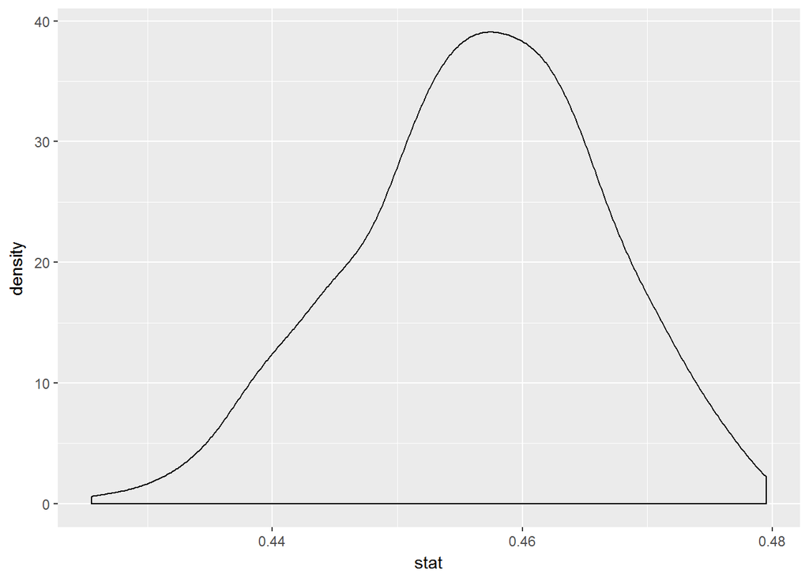

```r
# 3. 신뢰구간 구하기 -----
## 3.1. 부츠트랩: 결혼과 비혼으로 구분
married_boots <- gss_cat_df %>%
    mutate(marital = fct_lump(marital, 1)) %>%
    specify(response = marital, success = "Married") %>%
    generate(reps = 500, type = "bootstrap") %>%
    calculate(stat = "prop")

## 3.2. 시각화
married_boots %>%
    ggplot(aes(x=stat)) +
      geom_density()
```

```r
## 3.3. 신뢰구간
### 3.3.1. 부츠트랩 신뢰구간
married_se <- married_boots %>%
    summarize(se = sd(stat)) %>%
    pull()

c(married_hat - 2 * married_se, married_hat + 2 * married_se)
```

```
[1] 0.4364035 0.4761261
```

## 정규분포 가정 신뢰구간

$$\text{표준오차(SE)}=\sqrt{\frac{\hat{p}\times(1-\hat{p})}{n}}$$

이를 바탕으로 부츠트랩 혼인비율에 대한 신뢰구간을 시각화하고, 계산하면 다음과 같다. 부츠트랩으로 산출한 혼인비율에 대한 추정값과 신뢰구간이 근사적으로 동일함이 확인된다.

```r
### 3.3.2. 정규분포 신뢰구간
### 가정 검사
nrow(gss_cat_df) * married_hat >= 10
```

```
[1] TRUE
```

```r
nrow(gss_cat_df) * (1 - married_hat) >= 10
```

```
[1] TRUE
```

```r
### SE 계산
married_approx_se <- sqrt(married_hat * (1 - married_hat) / nrow(gss_cat_df))
c(married_hat - 2 * married_approx_se, married_hat + 2 * married_approx_se)
```

```
[1] 0.4364911 0.4760384
```

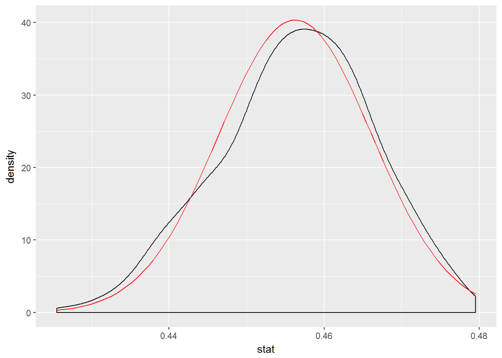

```r
## 3.4. 시각화
married_boots %>%
    ggplot(aes(x=stat)) +
    geom_density() +
    stat_function(fun = dnorm, args = list(mean = married_hat, sd=married_approx_se), color = "red")
```

# 비율 검정

| 표본 | 반응 범주 | 검정 |
| --- | --- | --- |
| 1 | 2 | 단일 표본 $\chi^2$ 검정, 이항 검정(Binomial Test) |
| 1 | 2 이상 | 단일 표본 $\chi^2$ 검정, 다항 검정(multinomial Test) |
| 1이상 | 2 이상 | $N$ 표본 $\chi^2$ 검정, G-검정, 피셔의 정확검정 |